# YouTube’s Ad Delivery Mechanism

## YouTube’s Ad Delivery Mechanism

Every time I open YouTube, the first thing I see is an ad that you can’t skip without a subscription, a brand I’ve never heard of, a poorly made-up game promotion that looks completely unplayable, or an app trying to get me to trade stocks… and a five-second countdown icon. I started thinking about the mechanisms behind these ads.

*Every time an ad appears during video playback, I fill out a Google Form, recording four pieces of information: the ad category, the ad duration, whether it’s the first time I’ve seen the ad that day, and an automatically generated timestamp. Over time, I’ve accumulated 48 records*.

## Gaming dominates ， but education has a hidden weapon

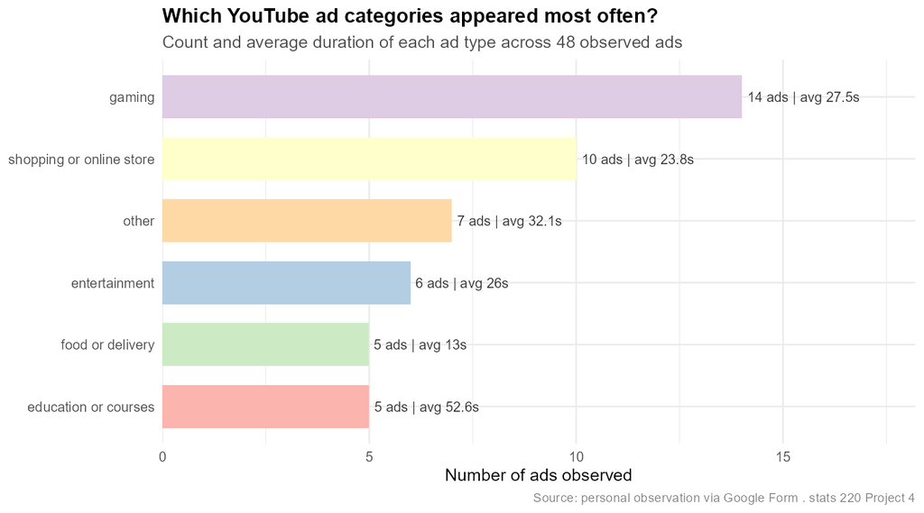

Horizontal bar chart titled ‘Which YouTube ad categories appeared most often?’. Six pastel bars rank ad categories by frequency: gaming with 14 ads and an average duration of 27.5 seconds, shopping or online store with 10 ads at 23.8 seconds, other with 7 ads at 32.1 seconds, entertainment with 6 ads at 26 seconds, food or delivery with 5 ads at 13 seconds, and education or courses with 5 ads at 52.6 seconds.

The headline is what you’d expect: **gaming ads come up the most**, 14 of them across my 48 observations — almost three in every ten.

But note the labels on the right side of each bar. They show the average duration of ads in each category. Food and takeout ads stay at **13 second**s—like a quick visual treat trying to whet your appetite. Most other categories of ads lasted between 20 and 30 seconds. Then there’s**Education and Courses**: although only 5 ads appeared, each averaged **52.6** seconds—nearly a minute, four times the length of a food ad. If a learning platform really captivates you, it’s ruthless.

## I’ve definitely seen you before… does that mean a shorter ad?

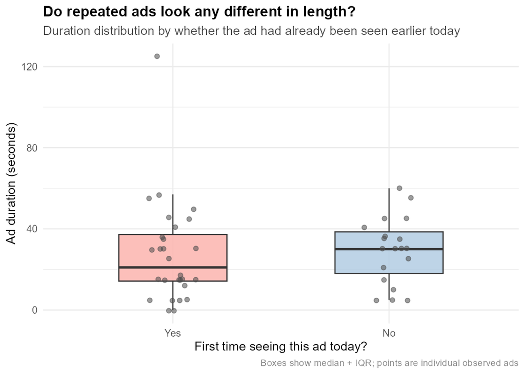

Box plot titled ‘Do repeated ads look any different in length?’. The x-axis splits the data into ‘Yes’ (pink box, first time today) and ‘No’ (blue box, repeated). Both boxes are similar in spread, sitting roughly between 15 and 40 seconds, but the Yes group has a single dramatic outlier point sitting at 125 seconds. The No group’s median sits slightly higher than the Yes group’s median.

You might assume YouTube would be merciful: if you’ve already sat through an ad once today, maybe the next time would be a snappy 5-second version? **My data says no.**

Repeated ads actually sit slightly *higher* on the duration axis than first-time ads — their median is around 30 seconds, compared with about 20 seconds for first-time ones. And the single most epic ad I logged — **a 125-second monster** — was actually a *first encounter*. So YouTube’s logic seems to be: if you’ve seen it once, you can sit through the whole thing again.

## Gaming at night, studying after lunch

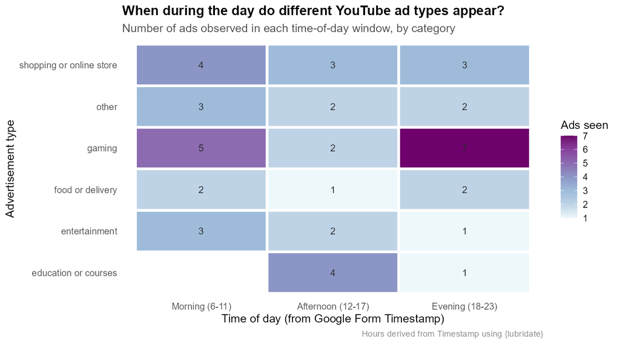

Heatmap titled ‘When during the day do different YouTube ad types appear?’. Rows are six ad categories, columns are three time-of-day windows (Morning 6 to 11, Afternoon 12 to 17, Evening 18 to 23). The cells are coloured in shades of pastel purple by count. Gaming ads peak at evening with 7 observations and morning with 5. Education or courses ads appear 4 times in the afternoon, only 1 in the evening, and 0 in the morning. Shopping ads are spread evenly. Food and entertainment ads appear in small numbers across all windows.

This is where the data got loud. pull the hour out of each Google Form timestamp, I split the day into three windows and counted what kind of ads turned up in each one.

**Gaming ads cluster in the evening**: 7 of my 14 gaming ads showed up between 6pm and midnight — exactly the prime time gamers are online. **Education ads do the opposite**: 4 out of 5 appeared in the *afternoon*, none in the morning, and only one straggler at night. Two ad categories with almost mirror-image schedules.

There’s another quiet detail: there’s no “late night (0-5)” column at all. YouTube didn’t fail to show me ads then — I never opened YouTube then. The empty column is a portrait of my sleep schedule.

## 48 ads later

Forty-eight ads isn’t a huge dataset, but it’s enough for the patterns to stop being noise. YouTube isn’t just shoving random products at me — **the category, the length, and the time of day are all coordinated**. Food ads stay short because they’re impulse triggers. Education ads run long because the pitch is complicated. Gaming ads ride the evening wave. Education ads catch the post lunch slump.